# Real-Time Location System - Case Study Unit 6

#### Cory Adams, Chris Boomhower, Alexandra Fisher, Alex Frye

#### MSDS 7333, October 11, 2017

## Abstract

This case study was undertaken in order to highlight and address the use of real-time location system (RTLS) technology and WiFi signals to predict the location of a device within a college dormitory. Location prediction is achieved by application of the k-nearest neighbors (kNN) clustering technique to a real location data set. Both a weighted and unweighted kNN are used and performance of the two classification methods on the data is then evaluated and compared against simple average predictions to determine the best prediction method. While prediction estimates for both models appear fairly close, we find the weighted kNN distance methodolgy to have the greatest impact and thus be the best method for location prediction.

## Introduction

Real-time location systems (RTLS) are local systems comprised of tags, readers, and location sensing systems that function as a whole to accurately determine locations of people or objects in real-time. While GPS has become a ubiquitous solution for outdoor real-time locating, RTLS technology has evolved and become much more prevalent for indoor tracking. In this case study we investigate RTLS technology and the use of WiFi signals to predict location by applying k-nearest neighbors (kNN) to a real location data set. The data set used is comprised of MAC addresses from recorded connections made to routers within the college dormitory. WiFi signal strength is measured at every router (network access point) via a mobile scanning device, and by measuring signal strength for these routers at various locations we are able to create a reference dataset on which to base device position predictions.

Advanced clustering methods are then performed on the reference dataset through the application of weighted and unweighted kNN algorithms to predict device locations. This is accomplished by leveraging the kNN clustering technique to a set of signal strengths in which we average the known (x,y) values for these neighbors to predict location estimates of devices [1]. Alternatively, a weighted average is calculated and considered as a potentially better predictor. In this formulation, the weights are inversely proportional to the neighbors’ distance (measured in Received Signal Strength Indication, or RSSI) from the test observation, allowing inclusion of the k points that are nearest while differentiating between them by how close they actually are [1]. After implementing the alternative approach of the weighted average kNN, resulting predictions are analyzed and compared against the simple, average predictions to ultimately determine the optimal prediction method.

## Methods

The steps used for this analysis were: 1) data clean up and EDA; 2) signal strength analysis; 3) implementation of kNN average weighting approach; 4) implementation of kNN distance weighting approach; & 5) comparison of kNN approaches to determine the best location prediction method.

*Note that code used includes modified versions of R code function examples found in Data Science in R: A Case Studies Approach to Computational Reasoning and Problem Solving, Chapter 1, pages 3-40 [1].*

#### Data Import

For this case study we will use a dataset created by the University of Mannheim [1]. The “offline” dataset is an open-source dataset that can be found online at http://rdatasciencecases.org/Data/offline.final.trace.txt. This “offline” dataset will be used as the training dataset to build our prediction model. The dataset contains 146,080 data points and each data point consists of the following fields:

t = timestamp for each data point id = MAC address of the device conducting the scan pos = coordinates of the device conducting the scan degree = orientation of the device conducting the scan MACofResponse1 = MAC address of the first responding device MACofResponseN = MAC address of the Nth responding device

Multiple devices can respond to the scanning device (MACofResponse1 to MACofResponseN) and each of the responding devices provide the following data: - SignalStrength (Decibel-milliwatts dBm) - Frequency - Mode (access point=3, adhoc mode=1)

The code below reads in the “offline” dataset and outputs some simple observations about how many lines in the file are data versus comments.

```r
# Configure number format to two decimal places only
options(digits = 2)
library(formattable)
library(lattice)
library(fields)
seed = 123
# Import offline data and explore data
txt = readLines("Data/offline.final.trace.txt")
paste("Total # of lines in offline data =",length(txt))
```

```
[1] "Total # of lines in offline data = 151392"
```

```r
paste("Total # of comments in offline data =", sum(substr(txt, 1, 1) == "#")) #Check number of comment lines in offline data
```

```
[1] "Total # of comments in offline data = 5312"
```

```r
paste("Total # of non-comment lines =", length(txt) - sum(substr(txt, 1, 1) == "#"))
```

```
[1] "Total # of non-comment lines = 146080"
```

#### Adding Structure to the Data

This section of code allows us to manipulate the data with the goal of having it be easier to interpret and manage. Currently, the data is just a bunch of raw text lines with “;” separators between records.

The code below creates a function that allows us to iteratively create matrices for each line in the “offline” dataset and merge into a data frame we can begin to organize for analysis. All comments have been removed and the dataset is now represented as a data frame instead of raw text. The data frame is now 1,181,628 rows and 10 columns.

```r
lines = txt[ substr(txt, 1, 1) != "#" ]
# Following line expected to throw warnings since one of the positions contains no signal data; commenting out since this issue is addressed via the return(NULL) statement in the updated processLine function in this chunk
#tmp = lapply(lines, processLine)
processLine = function(x)
{
  tokens = strsplit(x, "[;=,]")[[1]]

  if (length(tokens) == 10)
    return(NULL)

  tmp = matrix(tokens[ - (1:10) ], , 4, byrow = TRUE)
  cbind(matrix(tokens[c(2, 4, 6:8, 10)], nrow(tmp), 6,
               byrow = TRUE), tmp)
}
options(error = recover, warn = 1)
tmp = lapply(lines, processLine)
offline = as.data.frame(do.call("rbind", tmp),
                        stringsAsFactors = FALSE)
dim(offline)
```

```
[1] 1181628      10
```

#### Cleaning the Data and Building a Representation for Analysis

In the previous section we cleaned the data and created a data frame named “offline” consisting of 1,181,628 rows and 10 columns. While the data is now organized, we must still remove unwanted/unnecessary rows, provide identifiable names to the variables, and convert the variable values to their proper type. At this point all the variables are represented as strings and our data clearly has several numerical values.

The code below provides a name for each of the 10 columns in the data frame and converts the time, position, and signal variables to numeric types. This is key for comparison and correlation of these variables. Since ad-hoc devices will not be used further, any rows with ad-hoc data are removed from the data frame. This also allows us to drop the type row since we now know all the types are access points. The output below demonstrates the data cleanup and variable conversions discussed. The result is 978,443 rows and 9 columns in our “offline” data frame.

```r
names(offline) = c("time", "scanMac", "posX", "posY", "posZ",
                   "orientation", "mac", "signal",
                   "channel", "type")
numVars = c("time", "posX", "posY", "posZ",
            "orientation", "signal")
offline[ numVars ] =  lapply(offline[ numVars ], as.numeric)
offline = offline[ offline$type == "3", ]
offline = offline[ , "type" != names(offline) ]
dim(offline)
```

```
[1] 978443      9
```

```r
offline$rawTime = offline$time
offline$time = offline$time/1000
class(offline$time) = c("POSIXt", "POSIXct")
unlist(lapply(offline, class))
```

```
      time1       time2     scanMac        posX        posY        posZ orientation         mac      signal     channel     rawTime
   "POSIXt"   "POSIXct" "character"   "numeric"   "numeric"   "numeric"   "numeric" "character"   "numeric" "character"   "numeric"
```

```r
summary(offline[, numVars])
```

```
      time                          posX         posY           posZ    orientation      signal
 Min.   :2006-02-11 01:31:58   Min.   : 0   Min.   : 0.0   Min.   :0   Min.   :  0   Min.   :-99
 1st Qu.:2006-02-11 07:21:27   1st Qu.: 2   1st Qu.: 3.0   1st Qu.:0   1st Qu.: 90   1st Qu.:-69
 Median :2006-02-11 13:57:58   Median :12   Median : 6.0   Median :0   Median :180   Median :-60
 Mean   :2006-02-16 08:57:37   Mean   :14   Mean   : 5.9   Mean   :0   Mean   :167   Mean   :-62
 3rd Qu.:2006-02-19 08:52:40   3rd Qu.:23   3rd Qu.: 8.0   3rd Qu.:0   3rd Qu.:270   3rd Qu.:-53
 Max.   :2006-03-09 14:41:10   Max.   :33   Max.   :13.0   Max.   :0   Max.   :360   Max.   :-25
```

```r
 summary(sapply(offline[ , c("mac", "channel", "scanMac")],
                as.factor))
```

```
                mac               channel                    scanMac
 00:0f:a3:39:e1:c0:145862   2462000000:189774   00:02:2D:21:0F:33:978443
 00:0f:a3:39:dd:cd:145619   2437000000:152124
 00:14:bf:b1:97:8a:132962   2412000000:145619
 00:14:bf:3b:c7:c6:126529   2432000000:126529
 00:14:bf:b1:97:90:122315   2427000000:122315
 00:14:bf:b1:97:8d:121325   2442000000:121325
 (Other)          :183831   (Other)   :120757
```

```r
offline = offline[ , !(names(offline) %in% c("scanMac", "posZ"))]
```

#### EDA - Orientation

Prior to conducting analysis of our data frame, we must explore some of the key variables to better understand what they contain and how we can use them. The first variable we explore is the orientation variable.

A quick look at the unique values in the orientation column show there are `203` in total, although we were expecting only 8 (based on 45 degree increments). The Empirical CDF figure below shows that while the values are not strictly in 45 degree increments, they are close to one of the expected values as shown in the box plot figure below. This means that while they are not exact, they are close to a target orientation value. The code below takes the orientation value from each row and assigns it to the closest expected orientation value.

```r
len.un.or <- length(unique(offline$orientation))
#pdf(file = "Geo_ECDFOrientation.pdf", width = 10, height = 7)
oldPar = par(mar = c(4, 4, 1, 1))
plot(ecdf(offline$orientation), pch = 19, cex = 0.3,
     xlim = c(-5, 365), axes = FALSE,
     xlab = "orientation", ylab = "Empirical CDF", main = "")
axis(2)
```

```r
axis(side = 1, at = seq(0, 360, by = 45))
par(oldPar)
```

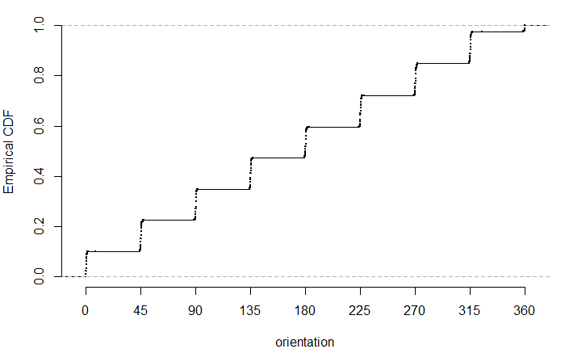

```r
roundOrientation = function(angles) {
  refs = seq(0, by = 45, length  = 9)
  q = sapply(angles, function(o) which.min(abs(o - refs)))
  c(refs[1:8], 0)[q]
}
offline$angle = roundOrientation(offline$orientation)
oldPar = par(mar = c(4, 4, 1, 1))
```

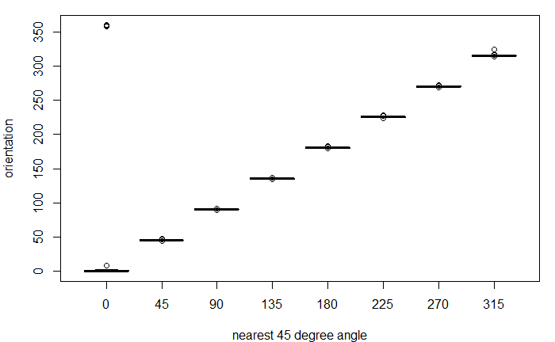

```r
with(offline, boxplot(orientation ~ angle,
    xlab = "nearest 45 degree angle",
    ylab="orientation"))
par(oldPar)
```

#### EDA - MAC Addresses

The next key variable in the dataset we will explore is the MAC address. Analysis shows 12 MAC addresses, while the experiment design only called for and discussed 6 MAC addresseses on the network. The code below shows each MAC address and the number corresponding records. Clearly there is a large variance between MAC addresses with a high number of records versus MAC addresses with a low number of records. In this case, the top 7 MAC addresses were kept in the dataset and the rest were removed.

The code below shows that the unique identifier for the MAC address corresponds with the identifier for channel, meaning these two values are essentially the same in our analysis and only one is necessary. No statistical significance will be gained by keeping both and if anything this could lead to unwanted correlation between variables.

```r
c(length(unique(offline$mac)), length(unique(offline$channel)))
```

```
[1] 12  8
```

```r
subMacs = names(sort(table(offline$mac), decreasing = TRUE))[1:7]
offline = offline[ offline$mac %in% subMacs, ]
macChannel = with(offline, table(mac, channel))
offline = offline[ , "channel" != names(offline)]
```

#### EDA - Hand-Held Device Position

The final variable we will explore is the position variable, or where the device was located within the experiment at the time of the data point. Each position variable recorded actually contains an X and Y value. The code below computes the total possible number of combinations for X and Y (`476`), checks if the values are null (`310`), and finally outputs non-null values (`166`). Knowing there are 166 positions where data was recorded, we can calculate the number of data points collected at each position. The matrix below shows the exact counts. While the number of data points per position are not equal, they are relatively close (~5,500). This means our data should not be biased by the position variable.

```r
locDF = with(offline,
             by(offline, list(posX, posY), function(x) x))
len.locDF = length(locDF)
sum.locDF.null = sum(sapply(locDF, is.null))
locDF = locDF[ !sapply(locDF, is.null) ]
len.locDF.nonull = length(locDF)
locCounts = sapply(locDF, nrow)
locCounts = sapply(locDF,
                   function(df)
                     c(df[1, c("posX", "posY")], count = nrow(df)))
locCounts[ , 1:8]
```

```
      [,1] [,2] [,3] [,4] [,5] [,6] [,7] [,8]
posX  0    1    2    0    1    2    0    1
posY  0    0    0    1    1    1    2    2
count 5505 5505 5506 5524 5543 5558 5503 5564
```

```r
oldPar = par(mar = c(3.1, 3.1, 1, 1))
locCounts = t(locCounts)
plot(locCounts, type = "n", xlab = "", ylab = "")
text(locCounts, labels = locCounts[,3], cex = .8, srt = 45)
```

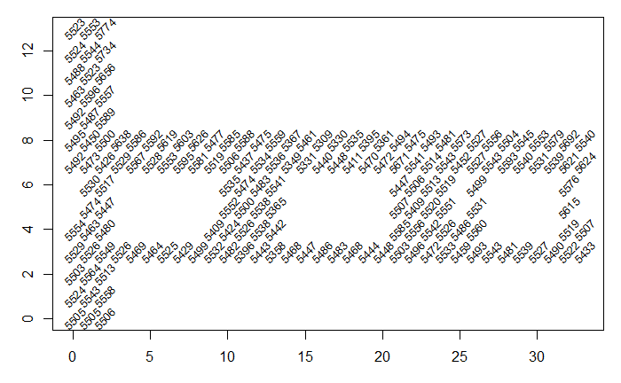

```r
par(oldPar)
```

#### Perform Cleanup as a Function

The previous steps (code blocks) provided clear instructions on how to read, structure, explore, and clean data from an external source.

Below is an optimized function (readData) that will allow us to download the same data and replicate the process shown above. The *readData()* function below completes all the tasks shown in “Data Import”, “Data Cleanup”, “Cleaning the Data and Building a Representation for Analysis”, “EDA - Orientation”, “EDA - MAC Addresses”, and “EDA - Hand-Held Device Position” efficiently. The output of this function results in the same dataset (“offline”) as displayed by comparing the dataset output by the readData function (“offlineRedo”). The two datasets are identical [identical(offline, offlineRedo) is `TRUE`], but this function is easier to update and deploy.

```r
readData =
  function(filename = 'Data/offline.final.trace.txt',
           subMacs = c("00:0f:a3:39:e1:c0", "00:0f:a3:39:dd:cd", "00:14:bf:b1:97:8a",
                       "00:14:bf:3b:c7:c6", "00:14:bf:b1:97:90", "00:14:bf:b1:97:8d",
                       "00:14:bf:b1:97:81"))
  {
    txt = readLines(filename)
    lines = txt[ substr(txt, 1, 1) != "#" ]
    tmp = lapply(lines, processLine)
    offline = as.data.frame(do.call("rbind", tmp),
                            stringsAsFactors= FALSE)

    names(offline) = c("time", "scanMac",
                       "posX", "posY", "posZ", "orientation",
                       "mac", "signal", "channel", "type")

     # keep only signals from access points
    offline = offline[ offline$type == "3", ]

    # drop scanMac, posZ, channel, and type - no info in them
    dropVars = c("scanMac", "posZ", "channel", "type")
    offline = offline[ , !( names(offline) %in% dropVars ) ]

    # drop more unwanted access points
    offline = offline[ offline$mac %in% subMacs, ]

    # convert numeric values
    numVars = c("time", "posX", "posY", "orientation", "signal")
    offline[ numVars ] = lapply(offline[ numVars ], as.numeric)
    # convert time to POSIX
    offline$rawTime = offline$time
    offline$time = offline$time/1000
    class(offline$time) = c("POSIXt", "POSIXct")

    # round orientations to nearest 45
    offline$angle = roundOrientation(offline$orientation)

    return(offline)
  }
offlineRedo = readData()
sameness = identical(offline, offlineRedo)
```

## Results

#### Signal Strength Analysis - Distribution of Signal Strength

The variable we want to understand from this experiment is the signal strength. Is the signal strength consistent across distances? Is it significantly impacted by the other variables we collected? We start by looking at the signal strength variable characteristics. The boxplot below shows the variance of the signal strength with multiple combinations of position and orientation. We also output a density plot to observe the variance of these combinations and as expected, there is a mixture of normal and skewed distributions. A closer look at the variance between signal strength and position show something interesting, which is that strong signals have a higher variance while weaker signals have a lower variance. This data was output using a summary of position, orientation, and access point combinations we will refer to as the “offlineSummary.”

```r
library(lattice)
bwplot(signal ~ factor(angle) | mac, data = offline,
       subset = posX == 2 & posY == 12
                & mac != "00:0f:a3:39:dd:cd",
       layout = c(2,3))
par(oldPar)
```

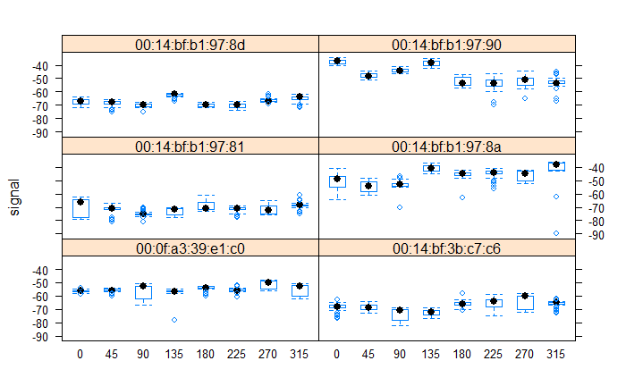

```r
oldPar = par(mar = c(3.1, 3, 1, 1))
```

```r
densityplot( ~ signal | mac + factor(angle), data = offline,
             subset = posX == 24 & posY == 4 &
                         mac != "00:0f:a3:39:dd:cd",
             bw = 0.5, plot.points = FALSE)
par(oldPar)
```

[figure not shown]

```r
offline = offline[ offline$mac != "00:0f:a3:39:dd:cd", ]
offline$posXY = paste(offline$posX, offline$posY, sep = "-")
byLocAngleAP = with(offline,
                    by(offline, list(posXY, angle, mac),
                       function(x) x))
signalSummary =
  lapply(byLocAngleAP,
         function(oneLoc) {
           ans = oneLoc[1, ]
           ans$medSignal = median(oneLoc$signal)
           ans$avgSignal = mean(oneLoc$signal)
           ans$num = length(oneLoc$signal)
           ans$sdSignal = sd(oneLoc$signal)
           ans$iqrSignal = IQR(oneLoc$signal)
           ans
           })
offlineSummary = do.call("rbind", signalSummary)
oldPar = par(mar = c(3.1, 3, 1, 1))
```

```r
breaks = seq(-90, -30, by = 5)
bwplot(sdSignal ~ cut(avgSignal, breaks = breaks),
       data = offlineSummary,
       subset = mac != "00:0f:a3:39:dd:cd",
       xlab = "Mean Signal", ylab = "SD Signal")
par(oldPar)
```

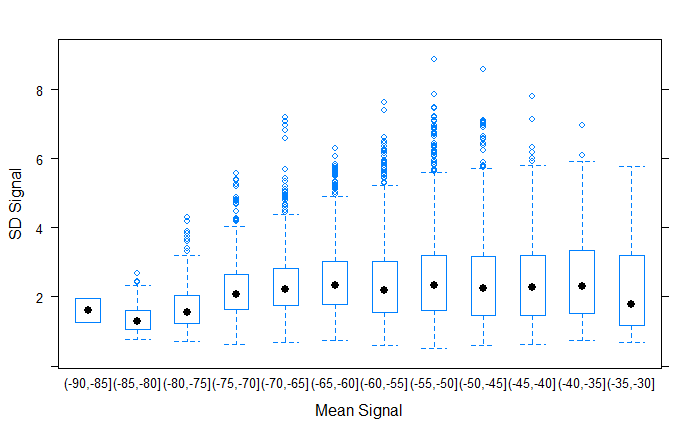

```r
oldPar = par(mar = c(4.1, 4.1, 1, 1))
```

```r
with(offlineSummary,
     smoothScatter((avgSignal - medSignal) ~ num,
                   xlab = "Number of Observations",
                   ylab = "mean - median"))
abline(h = 0, col = "#984ea3", lwd = 2)
```

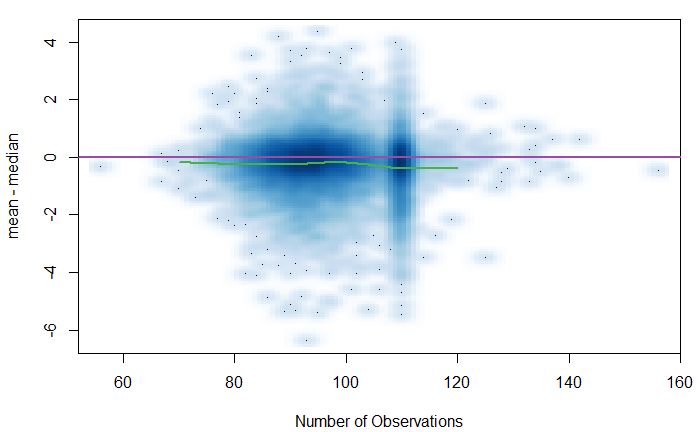

```r
lo.obj =
  with(offlineSummary,
       loess(diff ~ num,
             data = data.frame(diff = (avgSignal - medSignal),
                               num = num)))
lo.obj.pr = predict(lo.obj, newdata = data.frame(num = (70:120)))
lines(x = 70:120, y = lo.obj.pr, col = "#4daf4a", lwd = 2)
par(oldPar)
```

#### Relationship Between Signal and Distance

```r
oneAPAngle = subset(offlineSummary,
                    mac == subMacs[5] & angle == 0)
library(fields)
smoothSS = Tps(oneAPAngle[, c("posX","posY")],
               oneAPAngle$avgSignal)
vizSmooth = predictSurface(smoothSS)
plot.surface(vizSmooth, type = "C")
points(oneAPAngle$posX, oneAPAngle$posY, pch=19, cex = 0.5)
```

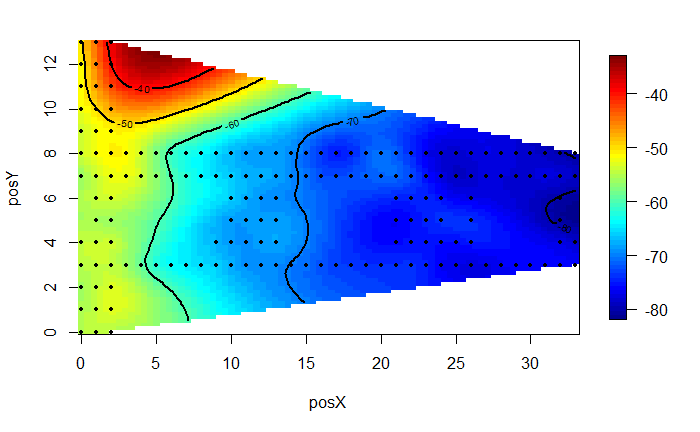

```r
surfaceSS = function(data, mac, angle = 45) {
  require(fields)
  oneAPAngle = data[ data$mac == mac & data$angle == angle, ]
  smoothSS = Tps(oneAPAngle[, c("posX","posY")],
                 oneAPAngle$avgSignal)
  vizSmooth = predictSurface(smoothSS)
  plot.surface(vizSmooth, type = "C",
               xlab = "", ylab = "", xaxt = "n", yaxt = "n")
  points(oneAPAngle$posX, oneAPAngle$posY, pch=19, cex = 0.5)
}
parCur = par(mfrow = c(2,2), mar = rep(1, 4))

par(parCur)
```

[figure not shown]

```r
offlineSummary = subset(offlineSummary, mac != subMacs[2])
AP = matrix( c( 7.5, 6.3, 2.5, -.8, 12.8, -2.8,
                1, 14, 33.5, 9.3,  33.5, 2.8),
            ncol = 2, byrow = TRUE,
            dimnames = list(subMacs[ -2 ], c("x", "y") ))
diffs = offlineSummary[ , c("posX", "posY")] -
          AP[ offlineSummary$mac, ]
offlineSummary$dist = sqrt(diffs[ , 1]^2 + diffs[ , 2]^2)
xyplot(signal ~ dist | factor(mac) + factor(angle),
       data = offlineSummary, pch = 19, cex = 0.3,
       xlab ="distance")
oldPar = par(mar = c(3.1, 3.1, 1, 1))
```

[figure not shown]

```r
library(lattice)
xyplot(signal ~ dist | factor(mac) + factor(angle),
       data = offlineSummary, pch = 19, cex = 0.3,
       xlab ="distance")
par(oldPar)
```

#### KNN Average Weighting

While there exist various techniques that may be used to estimate device location based on RSSI, this case study seeks to undertake a simple KNN clustering approach for test observation location determination. As such, a measure of Euclidean Distance, as depicted in the formula below, will be used to assess proximity of a test observation to the 166 potential neighbor locations:

$Euclidean Distance =\sqrt{(S_1^*-S_1)^2 + ...+ (S_6^*-S_6)^2}$

In this formula, $S_i$ represents the strength of a signal measured between a hand-held device and an $i$-th training observation access point recorded at a specific location. Similarly, $S_1^*$ represents the signal measured between the same access point and the new point under assessment whose $(x, y)$ coordinates we are interested in determining.

With much of our EDA complete and KNN prediction methodology defined, we need to next perform a few more preparatory actions before writing our model functions. Firstly, we create a unique location identifier column in our online data frame as follows.

```r
macs = unique(offlineSummary$mac)
online = readData("Data/online.final.trace.txt", subMacs = macs)
online$posXY = paste(online$posX, online$posY, sep = "-")
posXY.unique <- length(unique(online$posXY))
```

Based on the various X-Y combinations that have now been concatenated into a new column, we have `60` unique test locations available in the online dataset. With this in mind, we proceed to tally the number of RSSI values recorded at each location. The following output depicts 10 randomly sampled location tallies by orientation. This sampling reveals that RSSI values were recorded at only one orientation for each location.

```r
set.seed(seed = seed)
# Number of signal strengths recorded at each location
tabonlineXYA = table(online$posXY, online$angle)
tabonlineXYA[sample(1:nrow(tabonlineXYA), 10), ]
```

```
               0  45  90 135 180 225 270 315
  10.99-7.19   0   0   0   0   0   0 579   0
  28.12-7.57   0   0   0   0   0   0   0 595
  12.55-7.38 573   0   0   0   0   0   0   0
  31.78-7.62   0   0   0   0   0   0 612   0
  32.54-7.08   0 569   0   0   0   0   0   0
  0.31-11.09   0   0   0   0   0 573   0   0
  2.49-7.6     0   0   0   0   0   0   0 593
  29.58-7.93   0   0   0   0   0   0   0 579
  4.51-7.63    0   0   0   0   0   0   0 618
  9.08-7.24  550   0   0   0   0   0   0   0
```

With these added insights, we are ready to restructure the data into 6 columns of signal strengths rather than only a single signal strength column with all access points as has been done so far. This means that each access point will have its own column comprised of its respective RSSI values. This step will make it easier to compute distance between the 6 signal strength vectors. In so doing, we provide the average signal strength at each location as summary and depict the first 10% of these below (the first 6 locations comprise the first 10%). Notice 11 columns are present in our summary, including the concatinated X-Y values, X and Y values in their separate columns, orientation, angle, and the 6 access points’ average RSSI values.

```r
keepVars = c("posXY", "posX","posY", "orientation", "angle")
byLoc = with(online,
             by(online, list(posXY),
                function(x) {
                  ans = x[1, keepVars]
                  avgSS = tapply(x$signal, x$mac, mean)
                  y = matrix(avgSS, nrow = 1, ncol = 6,
                        dimnames = list(ans$posXY, names(avgSS)))
                  cbind(ans, y)
                }))
onlineSummary = do.call("rbind", byLoc)
head(onlineSummary)
```

|  | posXY | posX | posY | orientation | angle | 00:0f:a3:39:e1:c0 | 00:14:bf:3b:c7:c6 | 00:14:bf:b1:97:81 | 00:14:bf:b1:97:8a | 00:14:bf:b1:97:8d | 00:14:bf:b1:97:90 |
| --- | --- | --- | --- | --- | --- | --- | --- | --- | --- | --- | --- |
| 0-0.05 | 0-0.05 | 0.00 | 0.05 | 130.5 | 135 | -52 | -63 | -62 | -40 | -63 | -55 |
| 0.15-9.42 | 0.15-9.42 | 0.15 | 9.42 | 112.3 | 90 | -55 | -74 | -73 | -48 | -69 | -47 |
| 0.31-11.09 | 0.31-11.09 | 0.31 | 11.09 | 230.1 | 225 | -52 | -70 | -70 | -54 | -69 | -54 |
| 0.47-8.2 | 0.47-8.2 | 0.47 | 8.20 | 5.8 | 0 | -50 | -64 | -73 | -46 | -61 | -50 |
| 0.78-10.94 | 0.78-10.94 | 0.78 | 10.94 | 348.3 | 0 | -53 | -67 | -67 | -48 | -65 | -55 |
| 0.93-11.69 | 0.93-11.69 | 0.93 | 11.69 | 158.3 | 180 | -58 | -70 | -71 | -44 | -66 | -47 |

As part of our prediction process, our objective is to find offline data points that share similar orientations to our new location points since we discovered orientation impacts signal strength during our EDA efforts. To accomplish this, we select all records within a particular range of the test point’s orientation. As all observations were recorded in 45 degree increments, this becomes as easy as specifying the number of neighboring angles to include from the offline dataset. For even numbers, this means selecting even multiples of 45 degrees on each side of a test observation’s orientation angle. For odd numbers, it means selecting offline data with angles which match the new observation’s rounded orientation as well as those that flank the new observation’s angle. In the case where only one orientation is desired, offline data with angles matching the new observation’s will be selected only. The procedures to perform these actions, and to create a data structure aggregating the RSSI values from these angles, are as follows.

```r
reshapeSS = function(data, varSignal = "signal",
                     keepVars = c("posXY", "posX","posY")) {
  byLocation =
    with(data, by(data, list(posXY),
                  function(x) {
                    ans = x[1, keepVars]
                    avgSS = tapply(x[ , varSignal ], x$mac, mean)
                    y = matrix(avgSS, nrow = 1, ncol = 6,
                               dimnames = list(ans$posXY,
                                               names(avgSS)))
                    cbind(ans, y)
                  }))
  newDataSS = do.call("rbind", byLocation)
  return(newDataSS)
}
selectTrain = function(angleNewObs, signals = NULL, m = 1){
  # m is the number of angles to keep between 1 and 5
  refs = seq(0, by = 45, length  = 8)
  nearestAngle = roundOrientation(angleNewObs)

  if (m %% 2 == 1)
    angles = seq(-45 * (m - 1) /2, 45 * (m - 1) /2, length = m)
  else {
    m = m + 1
    angles = seq(-45 * (m - 1) /2, 45 * (m - 1) /2, length = m)
    if (sign(angleNewObs - nearestAngle) > -1)
      angles = angles[ -1 ]
    else
      angles = angles[ -m ]
  }
  angles = angles + nearestAngle
  angles[angles < 0] = angles[ angles < 0 ] + 360
  angles[angles > 360] = angles[ angles > 360 ] - 360
  angles = sort(angles)

  offlineSubset = signals[ signals$angle %in% angles, ]
  reshapeSS(offlineSubset, varSignal = "avgSignal")
}
```

To illustrate the performance of the above functions, below we depict the data structure created for an angle of 130 degrees using 3 angles in total (only first 6 rows shown). This, therefore, is an aggregation for angles of 90, 135, and 180 degrees. Note the average signal strengths are computed for the different angles by the *selectTrain()* function and that one set of signal strengths is created for each of the offline dataset’s `166` locations.

```r
train130 = selectTrain(130, offlineSummary, m = 3)
train130.nrow <- nrow(train130)
head(train130)
```

|  | posXY | posX | posY | 00:0f:a3:39:e1:c0 | 00:14:bf:3b:c7:c6 | 00:14:bf:b1:97:81 | 00:14:bf:b1:97:8a | 00:14:bf:b1:97:8d | 00:14:bf:b1:97:90 |
| --- | --- | --- | --- | --- | --- | --- | --- | --- | --- |
| 0-0 | 0-0 | 0 | 0 | -52 | -66 | -63 | -36 | -64 | -55 |
| 0-1 | 0-1 | 0 | 1 | -53 | -65 | -64 | -39 | -65 | -59 |
| 0-10 | 0-10 | 0 | 10 | -56 | -66 | -69 | -45 | -67 | -50 |
| 0-11 | 0-11 | 0 | 11 | -55 | -67 | -70 | -48 | -67 | -55 |
| 0-12 | 0-12 | 0 | 12 | -56 | -70 | -72 | -45 | -67 | -50 |
| 0-13 | 0-13 | 0 | 13 | -55 | -71 | -73 | -43 | -69 | -54 |

Once angle count functions are determined, the next step is to define a function to calculate distances between new points and all offline dataset observations. The following *findNN()* function is constructed to do just that, receiving 6 new signal strengths along with 6 offline signal strengths as output from the *selectTrain()* function. Locations of offline training observations are ordered by proximity to the new test observation’s RSSI values before being output by *findNN()*.

```r
findNN = function(newSignal, trainSubset) {
  diffs = apply(trainSubset[ , 4:9], 1,
                function(x) x - newSignal)
  dists = apply(diffs, 2, function(x) sqrt(sum(x^2)) )
  closest = order(dists)
  return(trainSubset[closest, 1:3 ])
}
```

As noted in our Methodology section, our first KNN prediction process simply averages the first k locations returned by the *findNN()* function. This procedure, along with the *findNN()*, *selectTrain()*, and *reshapeSS()* function calls, is embedded in the *predXY()* wrapper function as below.

*As indicated in our Methodology section, we will later be comparing the results of averaging the first k locations to weighting locations based on RSSI values.*

```r
predXY = function(newSignals, newAngles, trainData,
                  numAngles = 1, k = 3){

  closeXY = list(length = nrow(newSignals))

  for (i in 1:nrow(newSignals)) {
    trainSS = selectTrain(newAngles[i], trainData, m = numAngles)
    closeXY[[i]] =
      findNN(newSignal = as.numeric(newSignals[i, ]), trainSS)
  }
  estXY = lapply(closeXY,
                 function(x) sapply(x[ , 2:3],
                                    function(x) mean(x[1:k])))
  estXY = do.call("rbind", estXY)
  return(estXY)
}
```

Using the *predXY()* function, we illustrate location estimation accuracy for $k = 3$ and $k = 1$ KNN training counts. Furthermore, model fit is assessed by mapping actual and predicted locations with lines connecting the two points for each respective new observation. This map is first drawn for the 3-NN predictions below.

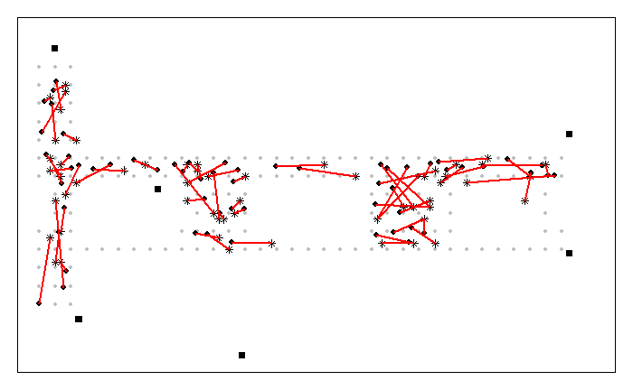

```r
estXYk3 = predXY(newSignals = onlineSummary[ , 6:11],
                 newAngles = onlineSummary[ , 4],
                 offlineSummary, numAngles = 3, k = 3)
estXYk1 = predXY(newSignals = onlineSummary[ , 6:11],
                 newAngles = onlineSummary[ , 4],
                 offlineSummary, numAngles = 3, k = 1)
floorErrorMap = function(estXY, actualXY, trainPoints = NULL, AP = NULL){

    plot(0, 0, xlim = c(0, 35), ylim = c(-3, 15), type = "n",
         xlab = "", ylab = "", axes = FALSE)
    box()
    if ( !is.null(AP) ) points(AP, pch = 15)
    if ( !is.null(trainPoints) )
      points(trainPoints, pch = 19, col="grey", cex = 0.6)

    points(x = actualXY[, 1], y = actualXY[, 2],
           pch = 19, cex = 0.8 )
    points(x = estXY[, 1], y = estXY[, 2],
           pch = 8, cex = 0.8 )
    segments(x0 = estXY[, 1], y0 = estXY[, 2],
             x1 = actualXY[, 1], y1 = actualXY[ , 2],
             lwd = 2, col = "red")
}
trainPoints = offlineSummary[ offlineSummary$angle == 0 &
                              offlineSummary$mac == "00:0f:a3:39:e1:c0" ,
                        c("posX", "posY")]
oldPar = par(mar = c(1, 1, 1, 1))
floorErrorMap(estXYk3, onlineSummary[ , c("posX","posY")],
              trainPoints = trainPoints, AP = AP)
```

The same is then done for the 1-NN predictions next. Note that upon comparison, errors are generally smaller for the 3-NN model than they are for 1-NN and that the largest errors tend to follow hallways rather than traverse large obstacles such as walls or other stationary barriers.

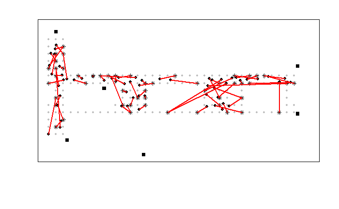

```r
floorErrorMap(estXYk1, onlineSummary[ , c("posX","posY")],
              trainPoints = trainPoints, AP = AP)
par(oldPar)
```

As further and more concrete assessment, we assess fits from the 3-NN and 1-NN models by comparing their Sum of Squared Error (SSE) values as follows.

```r
calcError =
function(estXY, actualXY)
   sum( rowSums( (estXY - actualXY)^2) )
actualXY = onlineSummary[ , c("posX", "posY")]
SSE <- sapply(list(estXYk1, estXYk3), calcError, actualXY)
```

Doing so reveals $k_1 SSE =$`659.4` and $k_3 SSE =$ `306.7`. This correlates with the visual summary we extracted from the error maps above and confirms that 3 nearest neighbors more accurately predict location when compred to only one nearest neighbor. Even so, we still need to determine if there is another k value that would even more accurately predict device location.

In order to avoid overfitting, we must identify the optimal value of k independent of our test observations. We use v-fold cross validation to do so. A $v$ value of 11 is selected since we have 166 different offline locations, allocating 15 locations to each fold. Allocations are randomly selected as follows (Note a warning is received since a $v$ of 11 does not divide evenly into 166; this is acceptable in our case).

```r
set.seed(seed = seed)
v = 11
permuteLocs = sample(unique(offlineSummary$posXY))
permuteLocs = matrix(permuteLocs, ncol = v,
                     nrow = floor(length(permuteLocs)/v))
```

```
data length [166] is not a sub-multiple or multiple of the number of rows [15]
```

```r
onlineFold = subset(offlineSummary, posXY %in% permuteLocs[ , 1])
```

After performing the above random allocations, the first 6 of `15` locations from our first fold are depicted below.

```r
head(onlineFold)
```

|  | time | posX | posY | orientation | mac | signal | rawTime | angle | posXY | medSignal | avgSignal | num | sdSignal | iqrSignal | dist |
| --- | --- | --- | --- | --- | --- | --- | --- | --- | --- | --- | --- | --- | --- | --- | --- |
| 73864 | 2006-02-11 02:47:06 | 0 | 3 | 0.2 | 00:0f:a3:39:e1:c0 | -53 | 1.1e+12 | 0 | 0-3 | -55 | -56 | 110 | 2.2 | 3.0 | 8.2 |
| 177657 | 2006-02-11 04:43:13 | 1 | 11 | 0.9 | 00:0f:a3:39:e1:c0 | -54 | 1.1e+12 | 0 | 1-11 | -54 | -54 | 110 | 1.7 | 1.0 | 8.0 |
| 474718 | 2006-02-11 11:34:55 | 13 | 6 | 0.1 | 00:0f:a3:39:e1:c0 | -53 | 1.1e+12 | 0 | 13-6 | -51 | -54 | 110 | 4.1 | 8.0 | 5.5 |
| 1168660 | 2006-03-09 14:26:17 | 19 | 8 | 359.9 | 00:0f:a3:39:e1:c0 | -57 | 1.1e+12 | 0 | 19-8 | -52 | -54 | 108 | 3.0 | 5.0 | 11.6 |
| 281516 | 2006-02-11 07:17:44 | 2 | 10 | 0.4 | 00:0f:a3:39:e1:c0 | -49 | 1.1e+12 | 0 | 2-10 | -53 | -52 | 110 | 5.6 | 6.0 | 6.6 |
| 288642 | 2006-02-11 07:23:24 | 2 | 11 | 0.5 | 00:0f:a3:39:e1:c0 | -55 | 1.1e+12 | 0 | 2-11 | -52 | -52 | 112 | 1.5 | 1.2 | 7.2 |

```r
onlineFold.ul <- nrow(unique(onlineFold[,2:3]))
```

Since we previously summarized our offline data into a structure containing 6 signal strength columns, one for each access point, we will do the same with our cross-validated test data. However, because it is easier to structure the test data in its complete form from offline data which is then divided into our desired folds, we now need to modify the *reshapeSS()* function as follows.

```r
reshapeSS = function(data, varSignal = "signal",
                     keepVars = c("posXY", "posX","posY"),
                     sampleAngle = FALSE,
                     refs = seq(0, 315, by = 45)) {

  set.seed(seed = seed)

  byLocation =
    with(data, by(data, list(posXY),
                  function(x) {
                    if (sampleAngle) { # conditional statement added for cross-validation
                      x = x[x$angle == sample(refs, size = 1), ]}
                    ans = x[1, keepVars]
                    avgSS = tapply(x[ , varSignal ], x$mac, mean)
                    y = matrix(avgSS, nrow = 1, ncol = 6,
                               dimnames = list(ans$posXY,
                                               names(avgSS)))
                    cbind(ans, y)
                  }))
  newDataSS = do.call("rbind", byLocation)
  return(newDataSS)
}
```

We now proceed to summarize and format the offline data using the updated *reshapeSS()* function to produce our online cross-validation summary data structure as below.

```r
offline = offline[ offline$mac != "00:0f:a3:39:dd:cd", ] #Look at all but MAC 00:0f:a3:39:dd:cd
keepVars = c("posXY", "posX","posY", "orientation", "angle")
onlineCVSummary = reshapeSS(offline, keepVars = keepVars,
                            sampleAngle = TRUE)
```

We’re now finally ready to determine the appropriate value for k based on our data. To do this, we calculate the SSE values for each value of k between 1 and 20. Doing this allows us to choose the k value which produces the smallest error among all k options.

```r
K = 20
err = rep(0, K)
for (j in 1:v) {
  onlineFold = subset(onlineCVSummary,
                      posXY %in% permuteLocs[ , j])
  offlineFold = subset(offlineSummary,
                       posXY %in% permuteLocs[ , -j])
  actualFold = onlineFold[ , c("posX", "posY")]

  for (k in 1:K) {
    estFold = predXY(newSignals = onlineFold[ , 6:11],
                     newAngles = onlineFold[ , 4],
                     offlineFold, numAngles = 3, k = k)
    err[k] = err[k] + calcError(estFold, actualFold)
  }
}
```

The SSE values produced for $k = 1$ through $k = 20$ are plotted for quick and easy review. The below figure plots the sum of fold SSE values with respect to each k count.

```r
oldPar = par(mar = c(4, 5, 1, 1))
plot(y = err, x = (1:K),  type = "l", lwd= 2,
     ylim = c(1200, 2100),
     xlab = "Number of Neighbors",
     ylab = "Sum of Square Errors")
rmseMin = min(err)
kMin = which(err == rmseMin)[1]
segments(x0 = 0, x1 = kMin, y0 = rmseMin, col = gray(0.4),
         lty = 2, lwd = 2)
```

```r
segments(x0 = kMin, x1 = kMin, y0 = 1100,  y1 = rmseMin,
         col = grey(0.4), lty = 2, lwd = 2)
mtext(kMin, side = 1, line = 1, at = kMin, col = grey(0.4))
```

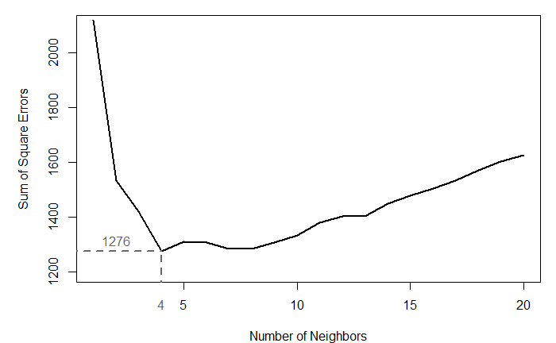

```r
text(x = kMin - 2, y = rmseMin + 40,
     label = as.character(round(rmseMin)), col = grey(0.4))
par(oldPar)
```

Based on our analysis, $k =$ `4` produces the least amount of error. This value differs from Nolan and Lang’s $k=5$ identified in their case study walkthrough due to our random sampling during *offlineSummary*, *onlineCVSummary*, and *permuteLocs* computation. Had we been provided the same seed value they used during their analysis, we would have obtained the same k result. However, since the difference is due to randomness alone, our $k=$ `4` is perfectly acceptable. With our optimal k defined, we may proceed with estimation to calculate final Sum of Squared Errors.

```r
estXYk4 = predXY(newSignals = onlineSummary[ , 6:11],
                 newAngles = onlineSummary[ , 4],
                 offlineSummary, numAngles = 3, k = kMin)
SSE.k4 <- calcError(estXYk4, actualXY)
```

Based on these results, $k_4 SSE =$`301.57`. This value is less than our previous reviews of $k_1 SSE$ and $k_3 SSE$ at `659.4` and `306.7` respectively. As expected, choosing an optimized value for k results in the most accurate model. It is this SSE value for $k=4$, `301.57`, that we will use to compare against our weighted distance KNN model.

#### KNN Distance Weighting

As we estimate position by average X-Y location across k nearest points, we begin to wonder if the distance of those points is relevant to the accuracy of the model. To test this, we apply weights to the X-Y positions of each k closest locations and take the sum of those results instead of averaging the values. With the below formula, we are able to compute weights for each k closest observations.

$$\begin{aligned}
\frac{1/d_i}{\sum_{i=1}^{k}1/d_i}
\end{aligned}$$

The *findNN()* function below has been modified from the previous version to also output the distance metrics utilized in determining the “closest” k points. Additionally, the *predXY()* function has been modified to compute weights with the formula above and distance outputs from the *findNN()* output. These weights are multiplied against each k nearest observation, respectively, then summed to compute a weighted estimation by distance. These new calculations may allow locations of closer distances to be more impactful than those further away - instead of equal weighting amongst the k points.

```r
#Modify findNN to also output the distances
findNN = function(newSignal, trainSubset) {
  diffs = apply(trainSubset[ , 4:9], 1,
                function(x) x - newSignal)
  dists = apply(diffs, 2, function(x) sqrt(sum(x^2)) )
  closest = order(dists)
  return(list(trainSubset[closest, 1:3 ],dists[order(dists)]))
}
#Modify findNN to utilize distance output for estimation efforts
predXY = function(newSignals, newAngles, trainData,
                  numAngles = 1, k = 3){

  closeXY = list(length = nrow(newSignals))
  closeDist = list(length = nrow(newSignals))

  for (i in 1:nrow(newSignals)) {
    trainSS = selectTrain(newAngles[i], trainData, m = numAngles)
    fnnResult =
    findNN(newSignal = as.numeric(newSignals[i, ]), trainSS)

    closeXY[[i]] = fnnResult[[1]]
    closeDist[[i]] = fnnResult[[2]]
  }


  distWeight = list(length = length(closeDist))

  for (i in 1:length(closeDist)){
    distW = list(length = k)
    for (j in 1:k){
      distW[j] = (1/closeDist[[i]][j])/sum(1/closeDist[[i]][1:k])
    }

    distWeight[[i]] =  distW
  }
  estXYDetails = list(length=length(closeXY))

  for(i in 1:length(closeXY)){
    estXYDetails[[i]] = as.matrix(closeXY[[i]][1:k,2:3]) * unlist(distWeight[[i]])
  }

  estXY = lapply(estXYDetails,
                 function(x) apply(x, 2,
                                   function(x) sum(x)))


  estXY = do.call("rbind", estXY)
  return(estXY)
}
```

```r
set.seed(seed = seed)
K = 20
err = rep(0, K)
for (j in 1:v) {
  onlineFold = subset(onlineCVSummary,
                      posXY %in% permuteLocs[ , j])
  offlineFold = subset(offlineSummary,
                       posXY %in% permuteLocs[ , -j])
  actualFold = onlineFold[ , c("posX", "posY")]

  for (k in 1:K) {
    estFold = predXY(newSignals = onlineFold[ , 6:11],
                     newAngles = onlineFold[ , 4],
                     offlineFold, numAngles = 3, k = k)
    err[k] = err[k] + calcError(estFold, actualFold)
  }
}
```

Once again, we perform fold tests on 1-20 k nearest neighbor estimations, this time utilizing the distance weighting modifications for each estimation. We save errors computed in each k iteration so we may plot results below.

```r
set.seed(seed = seed)
oldPar = par(mar = c(4, 5, 1, 1))
plot(y = err, x = (1:K),  type = "l", lwd= 2,
     ylim = c(1200, 2100),
     xlab = "Number of Neighbors",
     ylab = "Sum of Square Errors")
rmseMin = min(err)
kMin2 = which(err == rmseMin)[1]
segments(x0 = 0, x1 = kMin2, y0 = rmseMin, col = gray(0.4),
         lty = 2, lwd = 2)
```

```r
segments(x0 = kMin2, x1 = kMin2, y0 = 900,  y1 = rmseMin,
         col = grey(0.4), lty = 2, lwd = 2)
mtext(kMin2, side = 1, line = 1, at = kMin2, col = grey(0.4))
```

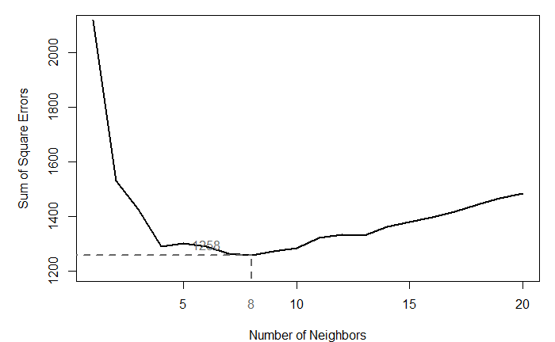

```r
text(x = kMin2 - 2, y = rmseMin + 40,
     label = as.character(round(rmseMin)), col = grey(0.4))
par(oldPar)
```

Plotting SSE values amongst the 20 k test iterations, we see that $kmin =$ `8` produces optimal results at a SSE value of 1258.39

```r
set.seed(seed = seed)
estXYk8 = predXY(newSignals = onlineSummary[ , 6:11],
                 newAngles = onlineSummary[ , 4],
                 offlineSummary, numAngles = 3, k = kMin2)
SSE.k8 <- calcError(estXYk8, actualXY)
```

With our optimal k value selected for number of nearest points, we compute predictions utilizing the weighted distance estimation method, storing the SSE values for comparison to the average location methods.

#### KNN Comparison

With optimal prediction method inputs defined for both average location estimation and weighted distance estimation, we compare estimations both visually and through SSE values. As can be seen below, Average Location Estimates vs Actual(top) and Weighted Distance Estimates vs Actual(bottom) plots help to describe how accurate the estimations were. Errors in both models seem to struggle the most in narrow hallways. This large error makes sense, given the fewer observations available for $k$ matches. OVerall, differences in these outputs show very similar results with some errors being largely minimized by the weighted distance strategy and others slightly increased. Although these measures appear fairly close to one another, it does appear as though the weighted distance methodology overall has a greater impact.

```r
oldPar = par(mar = c(1, 1, 1, 1))
par(oldPar)
floorErrorMap(estXYk4, onlineSummary[ , c("posX","posY")],
              trainPoints = trainPoints, AP = AP)
oldPar = par(mar = c(1, 1, 1, 1))
```

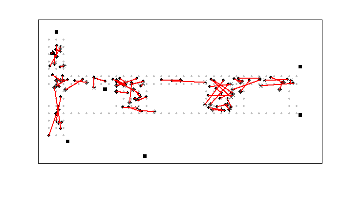

```r
par(oldPar)
```

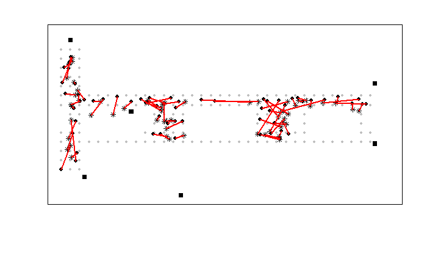

```r
floorErrorMap(estXYk8, onlineSummary[ , c("posX","posY")],
              trainPoints = trainPoints, AP = AP)
```

Our observations in the above visuals may be confirmed by comparing SSE values for each method. $k_{8WeightedDistance}SSE =$`267.41` through weighted distance estimation is `34.16` less than our previous reviews of $k_{4AverageLocation}SSE$ at `301.57` from the mean location nearest neighbor estimation. This aligns with our observations made from the visual error maps; weighted distance estimation provides more accurate results overall in the model. These weighted distances allow those k observations that are heavily skewed, with few observations of close distance and large number of observations of large distance, to be appropriately computed without biased input from the further distance points.

## Discussion and Future Works

As with outdoor GPS location services, RTLS ecosystems are becoming more ubiquitous. As RTLS usage increases, the need for accurate and innovative indoor location prediction models increases as well. In this case study, we’ve outlined the process of wrangling and structuring both offline training data as well as online training and test data, have performed detailed exploratory data analysis, and have generated kNN models with both averaged X-Y coordinates as well as weighted coordinates as a function of distance in the form of RSSI. While both models provided accurate estimates of device location, our model with weighted coordinates exhibited the least error. If implementing our RTLS system in production, we would thus choose our weighted coordinates as model configuration for location estimation.

As extension of this effort, future works would include both modifying our distance metrics as well as investigating other prediction algorithms to accomplish similar or better estimates. In terms of distance metrics, we might consider evaluating Chebyshev or Manhattan distance measures and comparing their estimation errors against those of kNN. Furthermore, new modeling methodologies might include artificial neural networks, K-Means clustering, or affinity propagation. Again, the estimation error of these prediction methods would be evaluated and compared against kNN as well.

## References

[1] D. Lang and D. Nolan, Data Science in R: A Case Studies Approach to Computation Reasoning and Problem Solving. New York, New York: CRC Press.